# 第11回 似た国を、グループに分ける

k-meansをwhileで書く・KMeans・グループの名前

# 導入

## 前回：分けるには、が残った

- 392台の車を、主成分の地図に置いた
- 「似た車どうしを、グループに分けるには」が残った

## 今日は、似たものを取り出す

- クラスタリング：データから、グループとして取り出す
- 正解のラベルは、ない

## あなたは、国際協力の担当者

- 142か国を、支援の方針が近いグループに分けたい
- 手がかりは、平均寿命と豊かさ

## 今日の問い

142か国を、平均寿命と豊かさから、支援の方針が近いグループに分けられるか？

## 今日のコードの書き方

- k-meansを、自分で書く
- `while`で、「動かなくなるまで」くり返す

## この問いに、どう近づくか

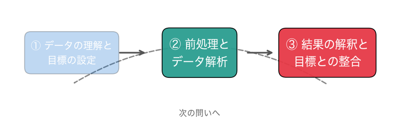

②でグループに分け、③で名前と方針をつけます。

# 0. 設定

## やってみよう：0節

- 第11回のノートを開き、ドライブにコピーする
- 0節の設定のセルを実行し、「セットアップ完了」を確かめる

動画の人は、ここで一時停止。

# 1. データを知る

## 分ける前に、散らばりを見る

- 手がかりは、平均寿命と一人あたりGDPの2列

## お手本：2007年の国を取り出す

```python
# データはこのリポジトリから読み込む
DATA_DIR = ('https://raw.githubusercontent.com/k0heiun0/'
            'applied_exercise_preview/main/shared/data')
df = pd.read_csv(f'{DATA_DIR}/gapminder.csv')
d = df[df['year'] == 2007].copy().reset_index(drop=True)
d['loggdp'] = np.log10(d['gdpPercap'])       # GDP の対数
print(len(d))
print(d[['lifeExp', 'loggdp']].describe().round(2))
```

- 役割：2007年の142か国を取り出し、GDPの対数の列を加える

## GDPは、対数にする

- GDPは277ドルから49357ドルまで、180倍近い開き
- 対数にすると、「10倍の違い」が同じ幅になる（第4回）

## 変えてみる：標準化する

```python
X = StandardScaler().fit_transform(d[['lifeExp', 'loggdp']])
print(X.shape, X.mean(axis=0).round(2), X.std(axis=0).round(2))
```

- 距離で近さを測るので、物差しをそろえる（第3回）

## やってみよう：1節

- 1節のお手本と「変えてみる」のセルを実行する
- 142か国は、どんなふうに散らばっているか？

動画の人は、ここで一時停止。

## 答え合わせ：142か国

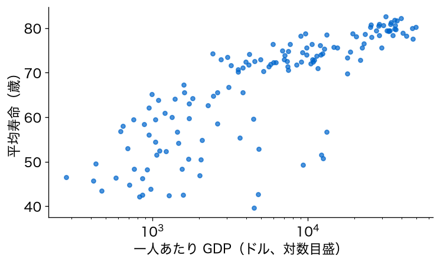

- 右上に固まった国々と、左下に広がる国々

## 平均0、標準偏差1

```
(142, 2) [0. 0.] [1. 1.]
```

- 標準化で、2つの列の物差しがそろった

# 2. k-meansを書く

## 物差しはそろった。どう分ける？

- 近い国どうしを、1つのグループに集めたい
- その手順の1つが、k-means

## k-meansの手順

1. K個の中心を、どこかに置く
2. 各点を、いちばん近い中心のグループに
3. 各グループの重心に、中心を動かす
4. 動かなくなるまで、2と3をくり返す

## おさらい：for

```python
for i in range(3):
    print(i)          # 0, 1, 2 と表示される
```

- 並びの中身を1つずつ名前に入れながら、字下げした行を繰り返す

## おさらい：[ ] の中のfor

```python
out = [i * 10 for i in range(3)]   # out は [0, 10, 20]
```

- 1つずつ式を計算して、結果をリストに集める（内包表記）

## お手本：1回ぶん

```python
centers = X[[0, 1, 2]]                    # 最初の3か国の位置を中心に
dist = np.column_stack([((X - c) ** 2).sum(axis=1) for c in centers])
labels = dist.argmin(axis=1)              # いちばん近い中心の番号
new = np.array([X[labels == j].mean(axis=0) for j in range(3)])
print(np.bincount(labels))                # グループごとの国の数
print(new.round(2))
```

## 距離の表を作る

```python
dist = np.column_stack([((X - c) ** 2).sum(axis=1) for c in centers])
```

- 1つの中心から、142か国それぞれへの距離の2乗
- `[… for c in centers]`：3つの中心それぞれで計算して、リストに集める
- 横に並べて（`column_stack`）、142行×3列の表

## いちばん近い中心を選ぶ

```python
labels = dist.argmin(axis=1)              # いちばん近い中心の番号
```

- `argmin(axis=1)`：行ごとに、いちばん小さい列の番号

## 重心に動かす

```python
new = np.array([X[labels == j].mean(axis=0) for j in range(3)])
```

- グループjの国だけを取り出し、平均の位置を求める

## 1回では、終わらない

- 中心が動けば、近い中心も変わる
- 割り当てをやり直し、また動かし……動かなくなるまで
- 何回かかるかは、前もってわからない

## while：条件のあいだ、くり返す

```python
while 条件:
    くり返す手順
```

- `for`：くり返す回数が決まっているとき
- `while`：条件がTrueのあいだくり返す

## おさらい：np.allclose

```python
np.allclose([1.0, 2.0], [1.0, 2.0000001])   # True
```

- 2つの配列がどこもほぼ等しければTrue（計算の誤差は無視）

## not：TrueとFalseを入れかえる

```python
not True                                     # False
```

- `not np.allclose(new, centers)`：等しくない（動いた）ならTrue

## 変えてみる：動かなくなるまで

```python
centers = X[[0, 1, 2]]
moved, n_iter = True, 0
while moved:                  # 中心が動いたあいだ、くり返す
    dist = np.column_stack([((X - c) ** 2).sum(axis=1)
                            for c in centers])
    labels = dist.argmin(axis=1)
    new = np.array([X[labels == j].mean(axis=0) for j in range(3)])
    moved = not np.allclose(new, centers)     # 動いたか
    centers = new
    n_iter += 1
print(n_iter, np.bincount(labels))
```

## 止めるのは、中の1行

```python
    moved = not np.allclose(new, centers)     # 動いたか
```

- 中心が動かなくなると、`moved`がFalseになって止まる
- 中で条件を変えないと、いつまでも止まらない

## やってみよう：2節

- 2節のお手本と「変えてみる」のセルを実行する
- 何回で、中心が動かなくなるか？

動画の人は、ここで一時停止。

## 最初の中心

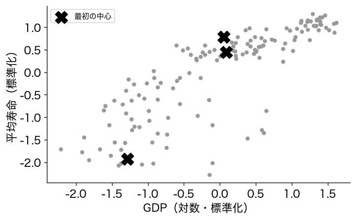

- 最初の3か国（アフガニスタン・アルバニア・アルジェリア）の位置

## 1回目：割り当てる

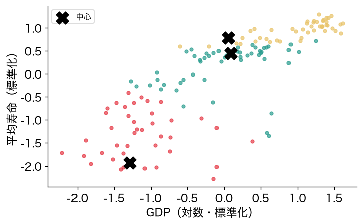

- 各国を、いちばん近い中心の色に

## 1回目：中心を動かす

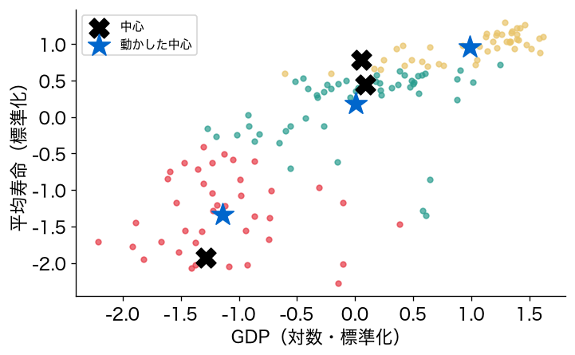

- 黒の×から、青の★（重心）へ

## 2回目

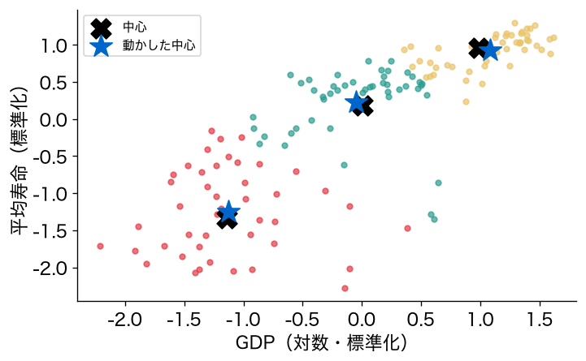

- 中心が動いたので、色の境目も動く

## 5回目で、止まる

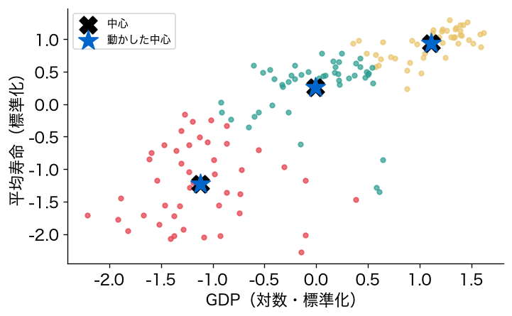

- ×と★が重なった。もう動かない

## 答え合わせ：5回

```
5 [46 47 49]
```

- 5回で止まった。国の数は46・47・49

# 3. KMeansで答え合わせ

## 自分で書けた。合っているか？

- scikit-learnの`KMeans`と、結果を比べる

## お手本：同じ出発点で比べる

```python
km1 = KMeans(n_clusters=3, init=X[[0, 1, 2]], n_init=1).fit(X)
print(km1.n_iter_, adjusted_rand_score(labels, km1.labels_))
```

- 役割：自分のk-meansと同じ出発点で、`KMeans`を動かす

## ARI：2つの分け方の一致度

- 番号の付け方が違っても、同じ国どうしが同じグループなら1
- でたらめに分けたのと同じくらいなら0

## 変えてみる：出発点を10通り

```python
km = KMeans(n_clusters=3, n_init=10, random_state=42).fit(X)
print(round(km1.inertia_, 2), round(km.inertia_, 2))
print(round(adjusted_rand_score(km1.labels_, km.labels_), 2))
```

- `n_init=10`：乱数で選んだ出発点を10通り試し、いちばんよいものを残す
- 出発点は、たがいに離れた点を選びやすい工夫つき（初めの設定）

## 慣性：まとまりの物差し

- 各点から、自分のグループの中心までの距離の2乗の合計
- 小さいほど、よくまとまっている

## やってみよう：3節

- 3節のお手本と「変えてみる」のセルを実行する
- 自分のk-meansと、`KMeans`は一致するか？

動画の人は、ここで一時停止。

## 答え合わせ：完全に一致

```
5 1.0
```

- くり返しは同じ5回、ARIは1.0
- `KMeans`の中身は、今書いたwhileそのもの

## 答え合わせ：10通り試すと

```
54.67 53.75
0.73
```

- 慣性は54.67 → 53.75。10通り試したほうが、よくまとまる
- ARIは0.73。分け方も変わった

## 答えは、出発点で変わる

- 最初の3か国からの出発は、より悪い別の分け方で止まっていた
- 止まったところが、いちばんよいとは限らない
- これからは、10通り試した`km`を使う

# 4. グループに名前をつける

## 分け方は決まった。中身は？

- 10通り試した`km`の、3つのグループを見ていく

## 番号には、意味がない

- 結果は、グループの番号（0・1・2）だけ
- 中身を要約して、名前をつける

## TODO①：グループを要約する

```python
# TODO: グループごとの国の数・平均寿命・GDP の平均を表示する
# ヒント: d['cluster'] = km.labels_ のあと、
#         d.groupby('cluster').agg(国数=('country', 'size'), …)
...
```

## やってみよう：4節とTODO①

- TODO①：グループごとの国の数・平均寿命・GDPの平均
- それぞれ、どんな国のグループか？

動画の人は、ここで一時停止。

## 答え合わせ：3つのグループ

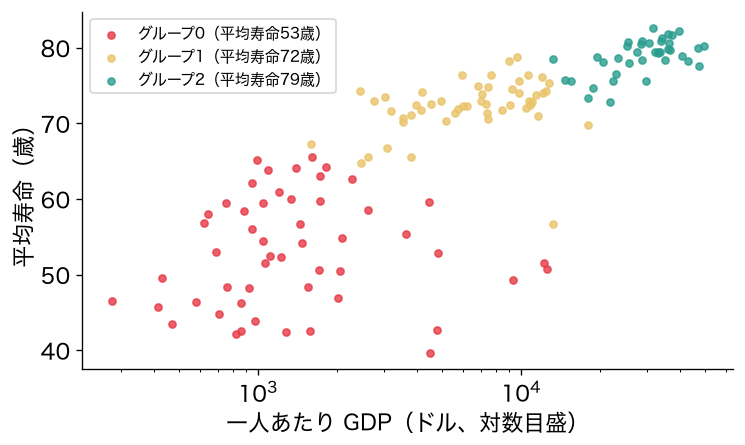

## 答え合わせ：TODO①

```
         国数  平均寿命      GDP
cluster
0        52  53.0   2079.0
1        51  72.0   7307.0
2        39  79.0  30201.0
```

## 最貧・新興・先進

- グループ0：53歳・約2100ドル → 最貧
- グループ1：72歳・約7300ドル → 新興
- グループ2：79歳・約3万ドル → 先進

# 5. 標準化しないと？

## 名前はついた。物差しを変えたら？

- 最貧・新興・先進は、標準化した2列で分けた結果

## 物差しをそろえた理由

- 1節で標準化したのは、2つの列の散らばりの大きさをそろえるため
- そろえないと、どうなるか

## TODO②：標準化せずに分ける

```python
# TODO: 標準化しない値で分けて、ARI とグループの要約を表示する
# ヒント: raw = KMeans(…).fit_predict(d[['lifeExp', 'loggdp']].values)
#         adjusted_rand_score(km.labels_, raw)
#         d.groupby(raw)[…].mean()
...
```

## やってみよう：5節とTODO②

- TODO②：標準化しない値で分けて、比べる

動画の人は、ここで一時停止。

## 答え合わせ：ARIは0.41

```
0.41
   lifeExp  gdpPercap
0     61.0     2172.0
1     76.0    18139.0
2     48.0     2479.0
```

- 分け方が、大きく変わった

## どの向きで、分かれたか

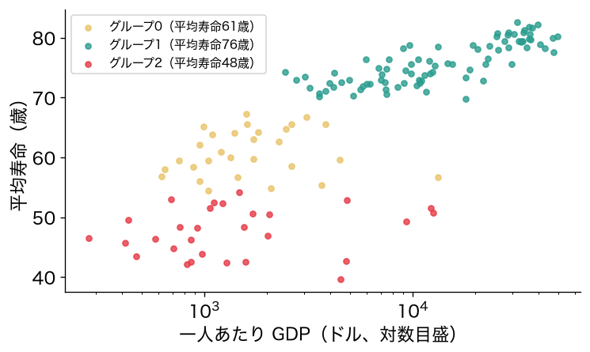

- 色の境目は、横（GDP）と縦（平均寿命）のどちらに沿うか

## 平均寿命だけで分けている

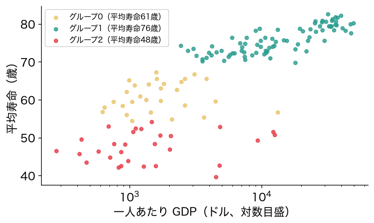

- 平均寿命は48・61・76歳と分かれるのに、GDPは2つのグループでほぼ同じ

## 散らばりの大きい列が、勝つ

- 平均寿命の標準偏差は12、GDPの対数は0.59。20倍の差
- 距離は、ほとんど平均寿命の差で決まる

## 距離で分けるなら、標準化

- 距離で分ける方法では、物差しをそろえることが欠かせない

# 6. 支援の方針

## 標準化は分かった。方針は？

- 最初の問いに戻り、3つのグループを方針の言葉で読む

## お手本：グループと大陸

```python
d['cluster'] = km.labels_
print(pd.crosstab(d['cluster'], d['continent']))
```

- 役割：グループと大陸の組み合わせごとに、国の数を数える

## TODO③：気になる国

```python
# TODO: 5か国のグループと、平均寿命・GDP を表示する
# ヒント: pick = ['Japan', 'China', 'India',
#                 'South Africa', 'Botswana']
#         d[d['country'].isin(pick)]
...
```

## TODO④：境目にいる国

```python
# TODO: 2つの中心までの距離の差が小さい5か国を表示する
# ヒント: dist = np.sort(km.transform(X), axis=1)
#         d['margin'] = dist[:, 1] - dist[:, 0]
#         → sort_values('margin')
...
```

- 2番目に近い中心と、いちばん近い中心の距離の差が小さい国

## やってみよう：6節とTODO③④

- 6節のお手本のセルを実行する
- TODO③：気になる国。TODO④：境目の国

動画の人は、ここで一時停止。

## 答え合わせ：グループと大陸

```
continent  Africa  Americas  Asia  Europe  Oceania
cluster
0              44         1     7       0        0
1               8        20    16       7        0
2               0         4    10      23        2
```

## 大陸と重なるが、同じではない

- 最貧の52か国のうち、44か国がアフリカ
- 先進の39か国のうち、23か国がヨーロッパ
- 新興は、アメリカ大陸とアジアを中心に、いろいろ混ざる

## 答え合わせ：TODO③

```
     country  cluster  lifeExp  gdpPercap
    Botswana        0     50.7    12569.9
       China        1     73.0     4959.1
       India        1     64.7     2452.2
       Japan        2     82.6    31656.1
South Africa        0     49.3     9269.7
```

## 2か国は、なぜ最貧に？

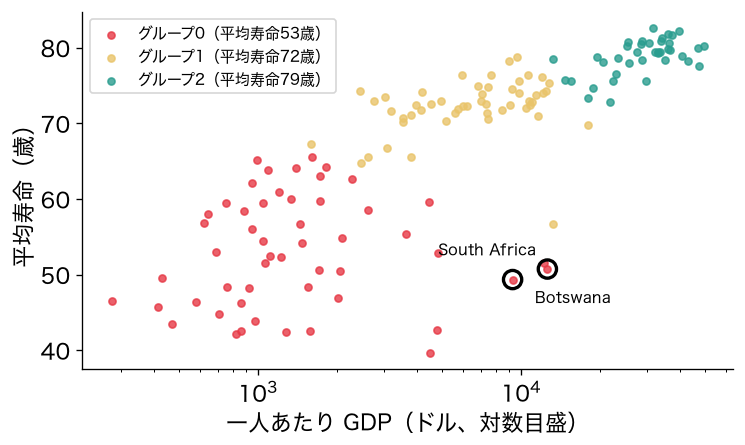

- 南アフリカとボツワナは、表ではグループ0（最貧）

## 寿命の短さで、最貧に

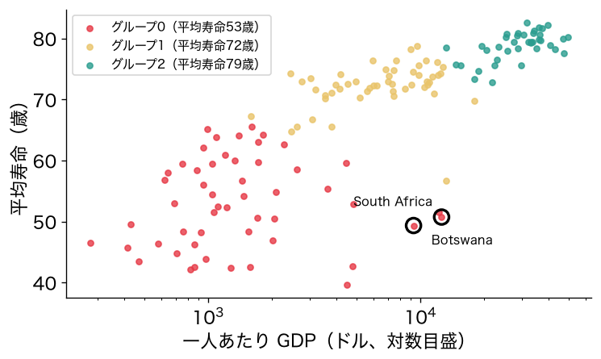

- GDPは新興並みなのに、平均寿命が49〜51歳と短い

## GDPだけでは、見落とす

- 平均寿命の短さは、HIVの流行の影響
- 2つの物差しで分けたから、見えた

## 答え合わせ：TODO④

```
            country  cluster  lifeExp  gdpPercap  margin
Trinidad and Tobago        1    69.82   18008.51    0.03
               Iraq        0    59.54    4471.06    0.07
   Korea, Dem. Rep.        1    67.30    1593.07    0.09
          Argentina        1    75.32   12779.38    0.09
             Mexico        1    76.19   11977.57    0.11
```

## 境目の国は、1か国ずつ

- トリニダード・トバゴ、イラク、北朝鮮、アルゼンチン、メキシコ
- 中心が少し動くだけで、別のグループに移りうる
- グループの方針をそのまま当てはめず、1か国ずつ確かめる

## 担当者の答え

142か国は、最貧（52）・新興（51）・先進（39）の3グループに分けられる。最貧は保健と経済の両面で、新興は経済の底上げを中心に支援する。境目の国は1か国ずつ確かめる。

## まだ言えないこと①：3つでよいか

- K＝3は、こちらで決めた数
- 4つや5つのほうが、よい分け方ではないのか

## まだ言えないこと②：ほかの方法

- k-meansのほかの方法で分けたら、同じグループになるか（課題）

# まとめ

## 今日の歩み

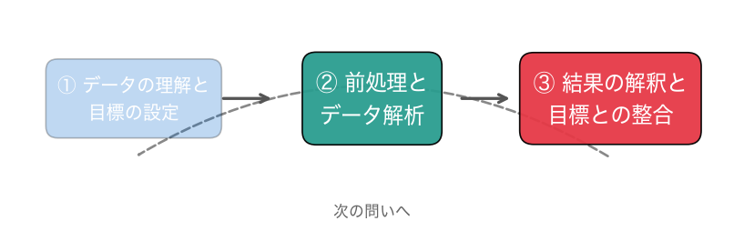

k-meansを書く → KMeansで確かめる → 名前をつける → 標準化の意味 → 方針

## 今日の要点

- k-meansは、割り当て → 重心へを、動かなくなるまでくり返す
- 答えは出発点で変わる。`n_init`で何通りも試し、慣性の小さいものを残す
- 番号に意味はない。要約して名前をつける
- 距離で分けるので、標準化で物差しをそろえる
- Python：`while 条件:`で、条件が成り立つあいだくり返す

## 課題の出し方

- ノートの最後の「課題（提出）」に取り組む
- 応用②の答えと応用③の文章を、LACSに入力して提出（＝出席。期限なし）
- AIを使ってもよい。何を聞いて、どう直したかを1行書く

## 次回予告：研究のコードを読む

- 実際の研究で使われているコードを読む
- 今日のような手順が、ファイルや関数に分かれて組み込まれている

## 次回の問い

論文のコードを読んで動かし、論文の主張を手元で確かめられるか？

## このあと：課題へ

ノートの「課題（提出）」へ。階層クラスタリングで分けると、k-meansと同じグループになるか。